# Notebook

## Practical: Rhythms and Scores

By the end of this practical you should able to:

- use `music21` to produce score representations of simple melodies
- create and listen to some rhythms with interesting properties
- use a simple counting approach to distinguish between various metrical prototypes

This notebook is for non-commercial use only.

## 1. Representing and typesetting melodies with `music21`

`music21` is a Python module that has been developed over the last 15 years or so, and can be useful for quick manipulations of score-based symbolic music representations, where information conveyed only by staff notation (e.g. key signatures, spelling, barlines etc.) is required for your application.

It is quite idiosyncratic, so we will only touch on it briefly in order to demonstrate the kinds of things a fully fledged score-based symbolic music representation should be able to do.

```python
from music21 import environment, stream, note, converter, corpus
from IPython.display import Image, Audio

import music21
import pretty_midi
import numpy as np
```

`music21` depends on several optional external binaries to support a variety of output formats. Here, we depend on a programme called GNU Lilypond, which is a music typesetting engine (think $\LaTeX$ for music). On NCC, `lilypond` lives at `/usr/bin/lilypond`. This may be different on your computer.

```python
environment.UserSettings()['lilypondPath'] = '/usr/bin/lilypond'
```

Please note that the support that `music21` has for `lilypond` is extremely limited; we just use it as an output format here because it produces images that do not have any other dependencies. You can use this convenience function (`show_object`) to typeset many `music21` objects.

```python
def show_object(music21_object):
    lpc = music21.lily.translate.LilypondConverter()
    lpc.loadFromMusic21Object(music21_object)
    path = lpc.createPNG()
    display(Image(filename=lpc.createPNG()))
    return path
```

Consider the following melody

[figure not shown]

We can construct this in `music21` as follows:

```python
s = music21.stream.Stream()
s.append(music21.key.Key('E-'))
s.append(music21.meter.TimeSignature('2/4'))

s.append(music21.note.Rest(quarterLength=0.5))
s.append(music21.note.Note('G4', quarterLength=0.5))
s.append(music21.note.Note('G4', quarterLength=0.5))
s.append(music21.note.Note('G4', quarterLength=0.5))
s.append(music21.note.Note('E4-', quarterLength=2))
```

Use `show_object` to typeset the `music21` `Stream` instance (it works with many types of `music21` object)

```python
path = show_object(s)
```

[output not shown]

### 1A

Create a `music21.stream.Stream()` that matches this score:

[figure not shown]

```python
q1a = music21.stream.Stream()
# vvvvvvvvvvvvvvvv
# Put your code here!
# ^^^^^^^^^^^^^^^^^
show_object(q1a)
```

[output not shown]

```
PosixPath('/tmp/music21/tmpbcn1fscv.ly.png')
```

### 1B

Create a `music21.stream.Stream()` that matches this score:

[figure not shown]

```python
q1b = music21.stream.Stream()
# vvvvvvvvvvvvvvvv
# Put your code here!
# ^^^^^^^^^^^^^^^^^
show_object(q1b)
```

[output not shown]

```
PosixPath('/tmp/music21/tmpzjyb43so.ly.png')
```

### 1C

Create a `music21.stream.Stream()` that matches this score:

[figure not shown]

```python
import copy

q1c = music21.stream.Stream()
# vvvvvvvvvvvvvvvv
# Put your code here!
# ^^^^^^^^^^^^^^^^^
```

[output not shown]

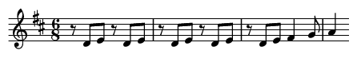

```
PosixPath('/tmp/music21/tmp80v8vl45.ly.png')
```

```python
show_object(q1c)
```

## Interlude. Common metrical patterns for a time signature

In this section, we look at how the time signature of piece of music relates to the kinds of rhythms that appear in it. To do this, we will examine rhythmic patterns in a large collection of folk songs, called the Essen corpus.

```python
import collections
import multiprocessing

from matplotlib import pylab as plt
from sklearn.decomposition import PCA
from sklearn.cluster import KMeans
from scipy.stats import gaussian_kde

def process_score(ep):
    data = collections.defaultdict(list)
    a = corpus.parse(ep)
    for s in a.scores:
        piece_start_times = []
        tses = list(s.flat.getElementsByClass('TimeSignature'))
        parts = list(s.parts)
        if len(tses) == 1 and len(parts) == 1:
            sig = tses[0].ratioString
            for m in s.parts[0].getElementsByClass('Measure'):
                measure_duration = m.duration.quarterLength
                measure_start_times = [note.offset / measure_duration for note in m.notes]
                piece_start_times.extend(measure_start_times)
            data[sig].append(piece_start_times)
    return data

def produce_rhythm_data():
    essen_pieces = corpus.getComposer('essenFolksong')
    num_cores = multiprocessing.cpu_count()

    with multiprocessing.Pool(num_cores) as pool:
        results = pool.map(process_score, essen_pieces)

    combined_data = collections.defaultdict(list)
    for result in results:
        for key, value in result.items():
            combined_data[key].extend(value)

    return combined_data

# takes 3m 7.6s on 8 cores in WSL2
data = produce_rhythm_data()
```

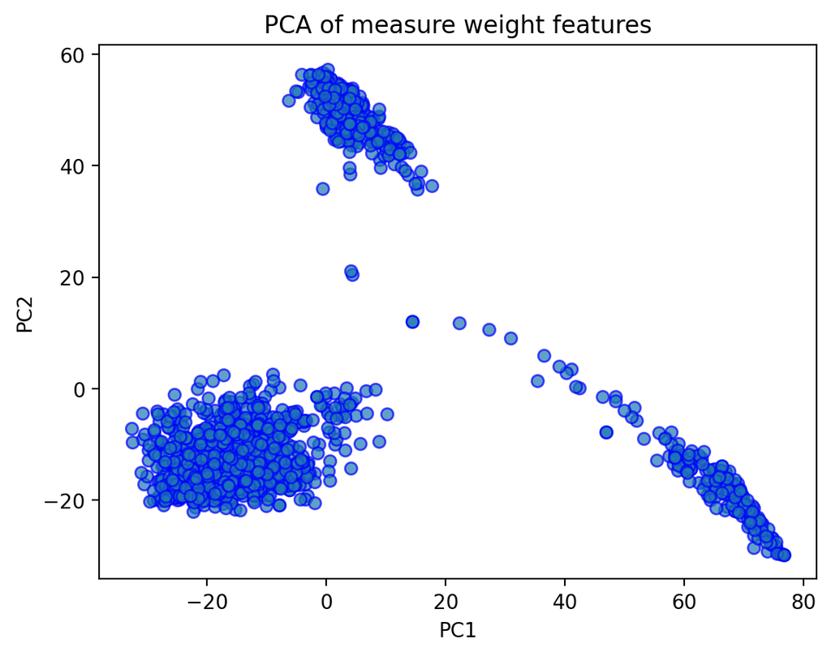

```python
all_features = []
for piece_counts in data['3/4']:
    if piece_counts != []:
        features, bins = np.histogram(piece_counts, bins=128, density=True)
        all_features.append(features)

X = np.array(all_features)
pca = PCA(n_components=2)
principal_components = pca.fit_transform(X)

plt.scatter(principal_components[:, 0], principal_components[:, 1], alpha=0.7, edgecolors='b')
plt.title('PCA of measure weight features')
plt.xlabel('PC1')
plt.ylabel('PC2')
plt.show()
```

## 3. Considerations when converting from score to MIDI

Consider the following melody again

[figure not shown]

The `music21` object can be converted to a series of `pretty_midi` `Notes` with onset times and durations. Hower, because `music21` is a score-based representation and `pretty_midi` deals with musical time in terms of seconds (which is better than "tick" time), we need to apply our understanding of tempo to figure out the start and end times of the notes.

```python
def m21_to_pm(m21_stream, bpm=120):
    pm = pretty_midi.PrettyMIDI()

    instrument = pretty_midi.Instrument(program=42)

    # beat_to_quarter is the ratio between beats and quarter notes
    beat_to_quarter = m21_stream.timeSignature.beatLengthToQuarterLengthRatio
    # beat_count is the number of beats in a measure (bar)
    beat_count = m21_stream.timeSignature.beatCount

    # vvvvvvvvvvvvvvvv
    # Put your code here!
    # ^^^^^^^^^^^^^^^^

    for note in m21_stream.notes:
        # offset is the start time of the note, measured in quarter notes
        # quarterLength is the duration of the note, measured in quarter notes
        offset, quarterLength = note.offset, note.quarterLength

        # vvvvvvvvvvvvvvvv
        # Put your code here!
        # ^^^^^^^^^^^^^^^^

    pm.instruments.append(instrument)

    return pm
```

## 4. A canon in augmentation by Josquin des Prez

We can define a transformation on melodies, called "augmentation", which increases the duration of every note by a constant factor. Write a function `augment(note_list, factor)` which augments a melody represented in `note_list`, which is a list of `pretty_midi` `Note`s by an arbitrary factor `factor`.

```python
def rhythm_augment(note_list, factor):
    augmented_notes = []
    for note in note_list:

        # vvvvvvvvvvvvvvvv
        # Put your code here!
        # ^^^^^^^^^^^^^^^^
    return augmented_notes
```

Now let's listen to the effect of combining these three augemented versions together:

```python
v1 = rhythm_augment(pretty_midi.PrettyMIDI('josquin.midi').instruments[0].notes, 1)
v2 = rhythm_augment(pretty_midi.PrettyMIDI('josquin.midi').instruments[0].notes, 3)
v3 = rhythm_augment(pretty_midi.PrettyMIDI('josquin.midi').instruments[0].notes, 3/2)
```

```python
prolation = pretty_midi.PrettyMIDI()

i1 = pretty_midi.Instrument(program=1)
i2 = pretty_midi.Instrument(program=2)
i3 = pretty_midi.Instrument(program=3)

i1.notes = v1

for note in v2:
    note.pitch -= 5

i2.notes = v2

for note in v3:
    note.pitch -= 12

i3.notes = v3

prolation.instruments = [i1, i2, i3]
```

```python
Audio(prolation.synthesize(fs=22050), rate=22050)
```

[interactive chart not shown]